# Population summary

Brian Knaus

2016-10-13

Many other examples exist at [Population_Genetics_in_R](http://grunwaldlab.github.io/Population_Genetics_in_R/).

This documents how the population summary figure from our population genetics review manuscript was created. Our example data set comes from the R package poppr. The data set consists of populations of the plant pathogen *P. infestans* which is thought to have a sexual mode or reproduction in Mexico but asexual elsewhere in the world. We load the package and the data as follows.

```r
library("poppr")
data("Pinf", package = "poppr")
Pinf
```

```
##
## This is a genclone object
## -------------------------
## Genotype information:
##
##    72 multilocus genotypes
##    86 tetraploid individuals
##    11 codominant loci
##
## Population information:
##
##     2 strata - Continent, Country
##     2 populations defined - South America, North America
```

This loads an object of class ‘genclone’ that contains our data into our environment. By calling the object by its name we’ve printed some information about it. Under ‘population information’ we see that there are two populations defined, one for South America and one for North America. We can subset the data to populations as follows.

```r
Pinf.l <- seppop(Pinf)
```

## Multilocus genotypes

When we sample from a population and genotype our samples we typically find that some individuals are identical based on our marker system. Each unique combination of alleles can be referred to as a multilocus genotype (MLG). We can count the number of multilocus genotypes with the function `mlg.table()`. This function will (optionally) create a plot of the data.

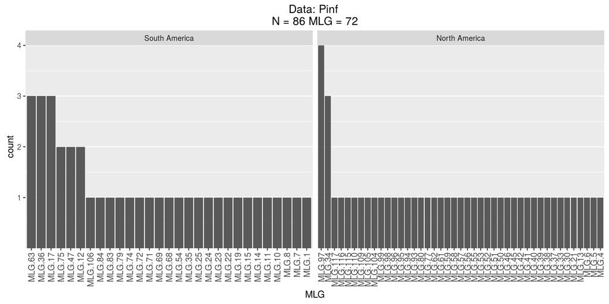

```r
mlg.table(Pinf, quiet = TRUE)
```

Here we’ll suppress the plot but save the data as elements of a list so we can make a custom plot later.

```r
pop.l <- vector("list", length=4)
pop.l[[1]] <- mlg.table(Pinf.l[[1]], plot = FALSE)
pop.l[[2]] <- mlg.table(Pinf.l[[2]], plot = FALSE)
```

When we sample microorganisms we do not necessarily know whether two samples represent different individuals or are different samples from the same clone. By removing samples from the data set that have identical multilocus genotypes we clone correct our data set.

```r
Pinf.l[[3]] <- clonecorrect(Pinf.l[[1]])
Pinf.l[[4]] <- clonecorrect(Pinf.l[[2]])
```

We can visualize how this affects the number of MLGs in our dataset by again using the `mlg.table` function.

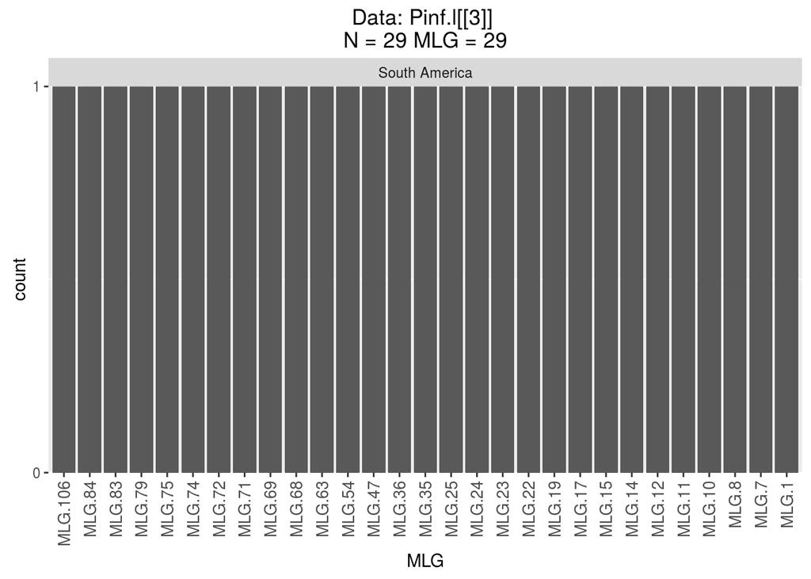

```r
pop.l[[5]] <- mlg.table(Pinf.l[[3]], plot = TRUE)
```

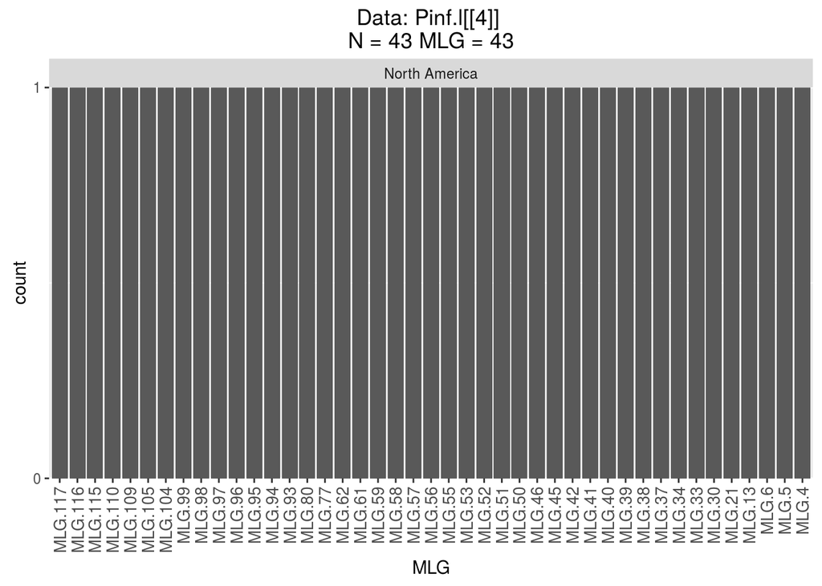

```r
pop.l[[6]] <- mlg.table(Pinf.l[[4]], plot = TRUE)
```

## Index of association

The correlation among allelic states at two loci is typically summarized as a measure of linkage disequilibrium. A summary of this relationship over many loci is the index of association. This index can help determine if a collection of loci demonstrate a deviation from linkage equilibrium.

[figure not shown]

```r
pop.l[[3]] <- ia(Pinf.l[[1]], sample=999, quiet=TRUE, valuereturn=T, hist = FALSE)
```

[figure not shown]

```r
pop.l[[4]] <- ia(Pinf.l[[2]], sample=999, quiet=TRUE, valuereturn=T, hist = FALSE)
```

```r
pop.l[[7]] <- ia(Pinf.l[[3]], sample=999, quiet=TRUE, valuereturn=T)
```

[figure not shown]

```r
pop.l[[8]] <- ia(Pinf.l[[4]], sample=999, quiet=TRUE, valuereturn=T)
```

[figure not shown]

The plots show a histogram of simulated data that are in linkages equilibrium. This forms our null hypothesis. The dashed line shows our statistic derived from our data. The population from South America has an $\bar{r}_{d}$ of 0.3 which is well beyond the limits of our simulations based on loci that are in equilibrium. The population from North America has an $\bar{r}_{d}$ of 0.008 which is within our null distribution. Bsed on this information we may conclude that the population from S. America is in linkage disequilibrium while the population from N. America is in a state of linkage equilibrium.

## Distance matrices

Distance matrices are a common way of summarizing multivariate data. Many options are available in a number of R packages. Here we use `diss.dist` from the package poppr.

```r
Pinf.l[[5]] <- diss.dist(Pinf.l[[1]], percent = FALSE)
Pinf.l[[6]] <- diss.dist(Pinf.l[[2]], percent = FALSE)
Pinf.l[[7]] <- diss.dist(Pinf.l[[3]], percent = FALSE)
Pinf.l[[8]] <- diss.dist(Pinf.l[[4]], percent = FALSE)
```

## Minimum spanning network

One way of visualizng the data in a distance matrix is with a minimum spanning network.

```r
Pinf.l[[9]] <- poppr.msn(Pinf.l[[1]], Pinf.l[[5]])
```

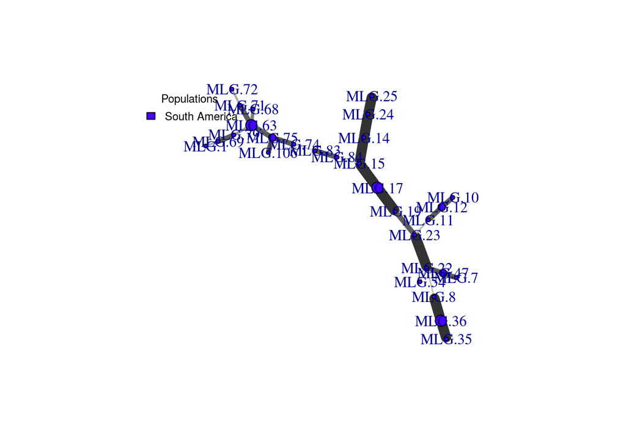

```r
Pinf.l[[10]] <- poppr.msn(Pinf.l[[2]], Pinf.l[[6]])
```

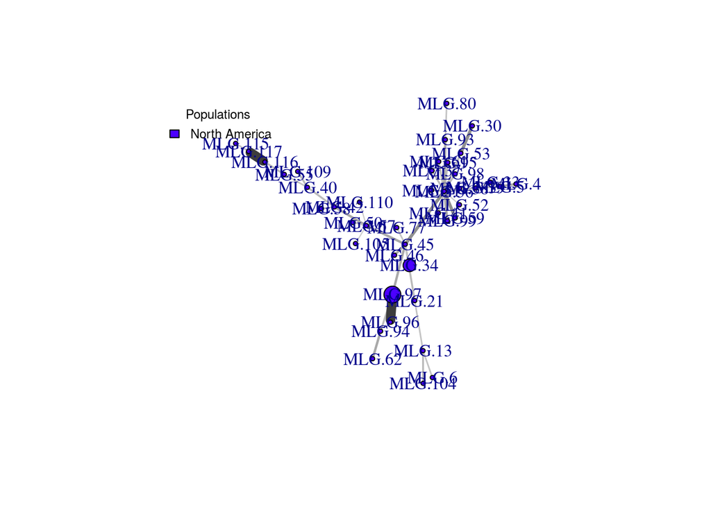

## Neighbor-joining trees

Another way of visualizng the data in a distance matrix is with a neighbor-joining tree.

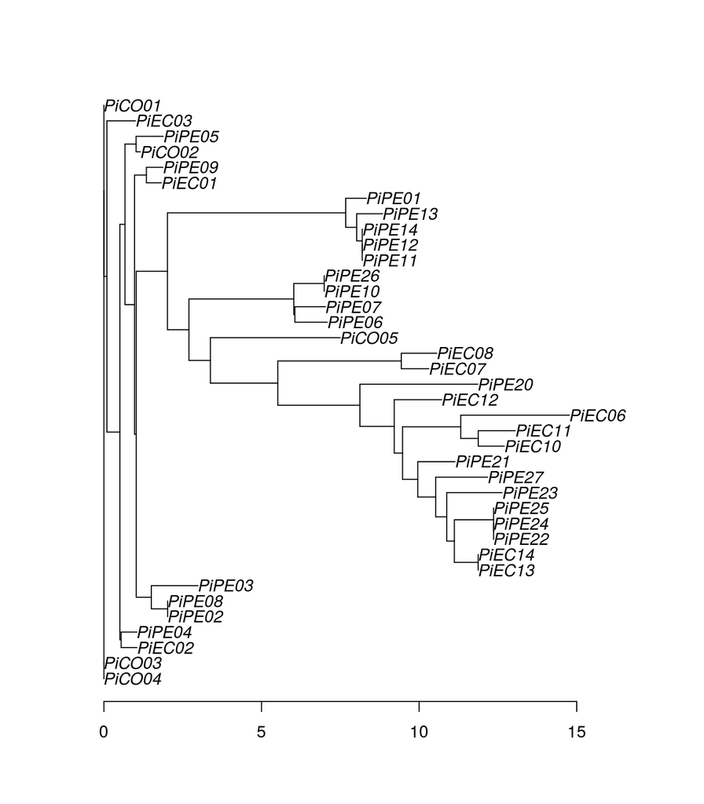

```r
library(ape)
Pinf.l[[11]] <- nj(Pinf.l[[5]])
Pinf.l[[12]] <- nj(Pinf.l[[6]])
plot(Pinf.l[[11]])
axis(side=1)
```

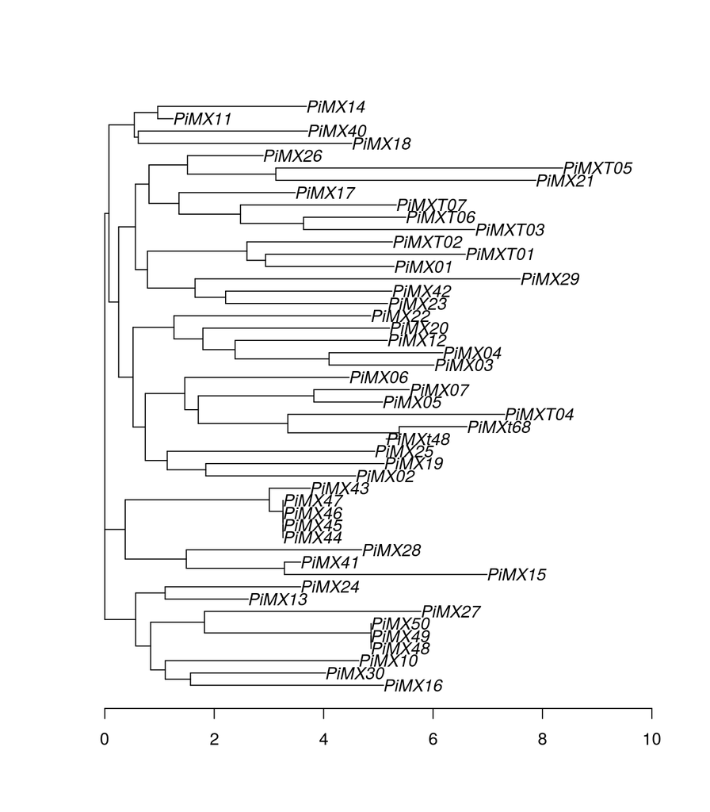

```r
plot(Pinf.l[[12]])
axis(side=1)
```

## Untrained clustering

A typical research question is how many groups exist within our sample. This can be addressed with untrained clustering methods. Here we use k-means clustering to determine the number of groups in our sample.

```r
Pinf.l[[13]] <- find.clusters(Pinf.l[[1]], max.n = 20, n.pca = 10, scale = FALSE, choose.n.clust=F, quiet=T)
Pinf.l[[14]] <- find.clusters(Pinf.l[[2]], max.n = 20, n.pca = 10, scale = FALSE, choose.n.clust=F)
Pinf.l[[15]] <- find.clusters(Pinf.l[[3]], max.n = 20, n.pca = 10, scale = FALSE, choose.n.clust=F)
Pinf.l[[16]] <- find.clusters(Pinf.l[[4]], max.n = 20, n.pca = 10, scale = FALSE, choose.n.clust=F)
```

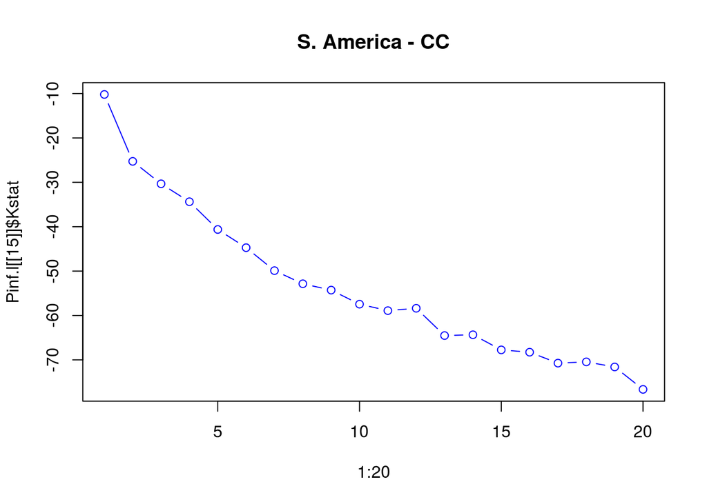

```r
#plot(1:20, Pinf.l[[13]]$Kstat, type='b', col=4, main="S. America")
plot(1:20, Pinf.l[[15]]$Kstat, type='b', col=4, main="S. America - CC")
```

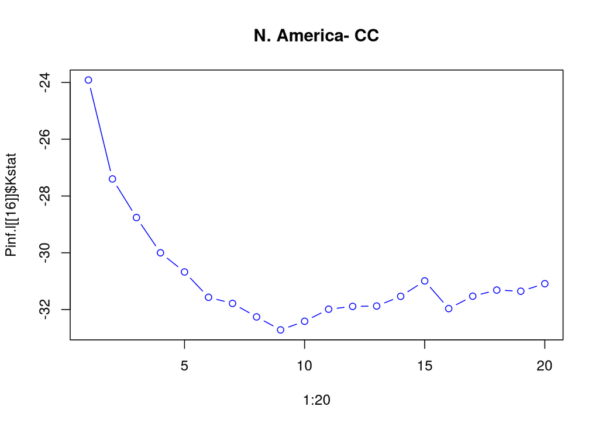

```r
#plot(1:20, Pinf.l[[14]]$Kstat, type='b', col=4, main="N. America")
plot(1:20, Pinf.l[[16]]$Kstat, type='b', col=4, main="N. America- CC")
```

## Creating a composite figure

We’ve implemented each of the steps above independently of one another. It is frequently nice to group multiple analyses into a single graphic with custom elements. Here we demonstrate how to use the information we’ve gathered above to create a custom graphic.

One analysis we’d like to include that was not performed in R was the Bayesian clustering software STRUCTURE. Here we read in the result from this program from a spreadsheet.

```r
library("readxl")
mex <- read_excel("./structure_out.xls", sheet = 'mx_k=4')
sa  <- read_excel("./structure_out.xls", sheet = 'sa_k=2')
```

Now we are ready to create a composite plot. We’ll use the function`layout` to specify the geometry of the plot. Then we’ll plot each frame.

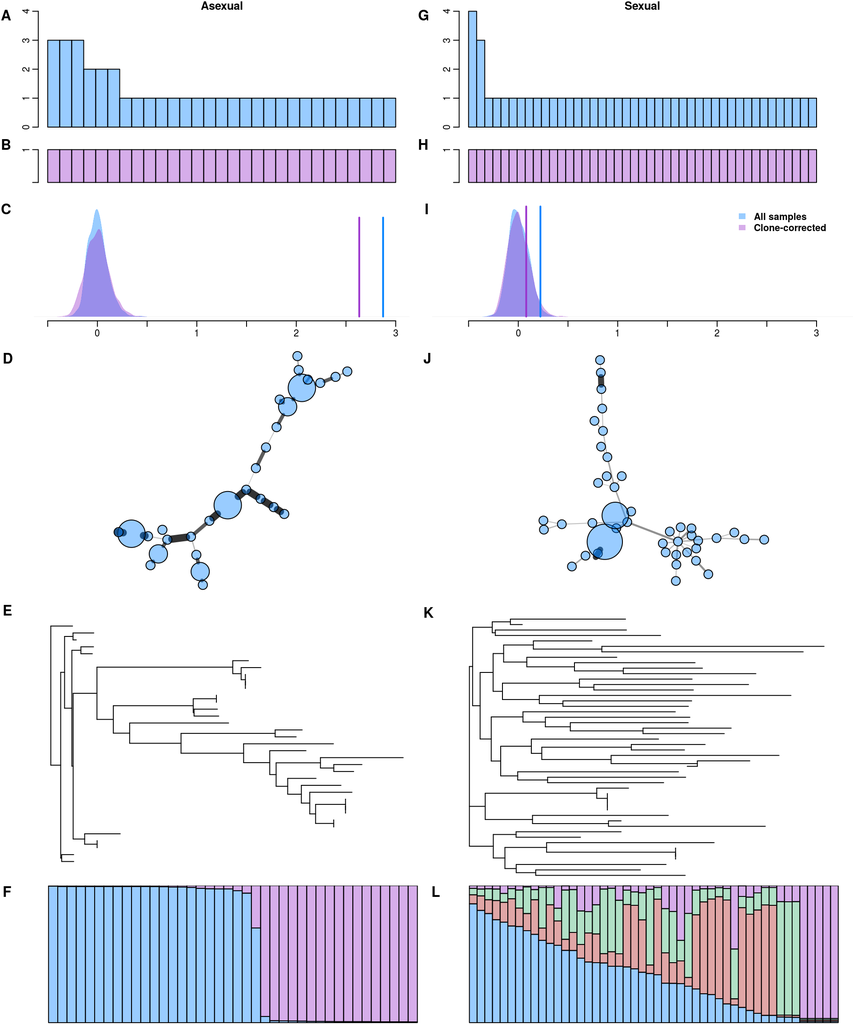

```r
library(igraph)
library(ape)

par(mfrow=c(1,1))
par(mar=c(5,4,4,2))


#tiff('popsum4.tiff', width=183, height=220, units='mm', pointsize=10, res=300)
#pdf('popsum4.pdf', width=7.2, height=8.66, pointsize=10)

par(oma=c(0,1,0,0))
panei <- 1

layout(matrix(1:12, ncol=2, nrow=6, byrow=F), widths=c(1,1), heights=c(1,0.4,1,2,2,1))

par(mar=c(1,2,1,2))
par(mgp=c(2, 0.6, 0))
barplot(sort(pop.l[[1]], decreasing=T),
        beside=T, las=3,
        names.arg=NA,
        col=c("#0080ff66"), space=0,
        ylim=c(0,4),
        axes=F)
title(main="Asexual")
axis(side=2, line= -0.4)
mtext("A", side=3, line=-1, font=2, adj= -0.09, cex=panei, srt=270)

barplot(sort(pop.l[[5]], decreasing=T),
        beside=T, las=3,
        names.arg=NA,
        col=c("#9932CC66"),
        space=0,
        ylim=c(0,1), axes=F)
axis(side=2, at=c(0,1), labels=c("", 1), line= -0.4)
mtext("B", side=3, line=-0.2, font=2, adj= -0.09, cex=panei)


d1 <- density(pop.l[[3]]$samples$Ia)
d2 <- density(pop.l[[7]]$samples$Ia)
#
plot(d1, main="", xlim=c(-0.5,3), xlab="", ylab="", type="n",
     axes=F)
polygon(d1, col="#0080ff66", border="#0080ff", lwd=0.1)
polygon(d2, col="#9932CC66", border="#9932CC", lwd=0.1)
lines(x=c(pop.l[[3]]$index['Ia'],pop.l[[3]]$index['Ia']), y=c(0,4), col="#0080ffff", lty=1, lwd=2)
lines(x=c(pop.l[[7]]$index['Ia'],pop.l[[7]]$index['Ia']), y=c(0,4), col="#9932CCff", lty=1, lwd=2)
axis(side=1, at=seq(-0.5, 3.0, by=0.5), labels=c("", 0, "", 1, "", 2, "", 3))
mtext("C", side=3, line=-1, font=2, adj= -0.09, cex=panei)


par(mar=c(0,2,0,0))
set.seed(1)
plot.igraph(Pinf.l[[9]]$graph, vertex.label=NA,
            vertex.size=get.vertex.attribute(Pinf.l[[9]]$graph, 'size')*8,
            edge.width=get.edge.attribute(Pinf.l[[9]]$graph, 'width')*0.75,
            vertex.color="#0080ff66")
mtext("D", side=3, line=-3, font=2, adj= -0.08, cex=panei)

par(mar=c(0,2,0,0))
ecol <- rep(1, times=nrow(Pinf.l[[11]]$edge))


ncolv <- rep(1, times=nrow(Pinf.l[[11]]$edge))
ncolv[1:3] <- 'white'
ncolv[4] <- 'white'
ncolv[73] <- 'white'

plot(Pinf.l[[11]], type="p", show.tip.label=F, edge.color=ncolv)
mtext("E", side=3, line= -0.8, font=2, adj= -0.08, cex=panei)

barplot(t(sa[,-1]), axes=F, col=c("#0080ff66","#9932CC66"), space=0)
mtext("F", side=3, line= -1.2, font=2, adj= -0.08, cex=panei)

##### Column 2 #####

par(mar=c(1,2,1,2))

barplot(sort(pop.l[[2]], decreasing=T),
        beside=T, las=3,
        names.arg=NA,
        col="#0080ff66", space=0,
        ylim=c(0,4), axes=F)
title(main="Sexual")
axis(side=2, line= -0.4)
mtext("G", side=3, line=-1, font=2, adj= -0.1, cex=panei)

barplot(sort(pop.l[[6]], decreasing=T),
        beside=T, las=3,
        names.arg=NA,
        col="#9932CC66", space=0,
        ylim=c(0,1), axes=F)
axis(side=2, line= -0.4, at=c(0,1), labels=c("", 1))
mtext("H", side=3, line=-0.2, font=2, adj= -0.1, cex=panei)


d1 <- density(pop.l[[4]]$samples$Ia)
d2 <- density(pop.l[[8]]$samples$Ia)
#
plot(d1, main="", xlim=c(-0.5,3), xlab="", ylab="", type="n",
     axes=F)
polygon(d1, col="#0080ff66", border="#0080ff", lwd=0.1)
polygon(d2, col="#9932CC66", border="#9932CC", lwd=0.1)
lines(x=c(pop.l[[4]]$index['Ia'],pop.l[[4]]$index['Ia']), y=c(0,4), col="#0080ffff", lty=1, lwd=2)
lines(x=c(pop.l[[8]]$index['Ia'],pop.l[[8]]$index['Ia']), y=c(0,4), col="#9932CCff", lty=1, lwd=2)
legend('topright', legend=c("All samples", "Clone-corrected"),
       fill=c("#0080ff66", "#9932CC66"),
       border=NA,
       bty="n", cex=1.0, text.font=2)
axis(side=1, at=seq(-0.5, 3.0, by=0.5), labels=c("", 0, "", 1, "", 2, "", 3))
mtext("I", side=3, line=-1, font=2, adj= -0.08, cex=panei)

par(mar=c(0,2,0,0))
set.seed(1)
plot.igraph(Pinf.l[[10]]$graph, vertex.label=NA,
            vertex.size=get.vertex.attribute(Pinf.l[[10]]$graph, 'size')*8,
            edge.width=get.edge.attribute(Pinf.l[[10]]$graph, 'width')*0.75,
            vertex.color="#0080ff66")
mtext("J", side=3, line=-3, font=2, adj= -0.08, cex=panei)

par(mar=c(0,2,0,0))
plot(Pinf.l[[12]], type="p", show.tip.label=F)
mtext("K", side=3, line=-1, font=2, adj= -0.08, cex=panei)

barplot(t(mex[,-1]), axes=F, col=c("#0080ff66","#B2222266", "#3CB37166", "#9932CC66"), space=0)
mtext("L", side=3, line= -1.2, font=2, adj= -0.06, cex=panei)
```

```r
#dev.off()
```

In order to create a graphic file uncomment either the ‘tiff’ or the ‘pdf’ statement at the top of the code chunck as well as the ‘dev.off()’ statement at the bottom (to close the file handle). This last graphic is a bit involved. But you can hopefully see the value in plotting each step individually before scaling to a composite plot as we’ve created here.